# Imports

```python
import calendar
from datetime import datetime

import numpy as np
import pandas as pd
import matplotlib.pyplot as plt
import missingno as msno
import seaborn as sns
from sklearn.linear_model import LinearRegression, Ridge, Lasso
from sklearn.ensemble import RandomForestRegressor
from sklearn.metrics import mean_squared_error
from xgboost import XGBRegressor
import optuna
from optuna.samplers import TPESampler
```

# Bike Sharing Demand Prediction

## 1. Load Data

Loading both training and test datasets from the Kaggle Bike Sharing Demand competition.

```python
train_df = pd.read_csv("train.csv")
test_df = pd.read_csv("test.csv")
```

## 2. Data Summary

- Dataset Shape and First Rows
- Data Types and Info
- Descriptive Statistics
- Missing Values

```python
print(f"Train shape: {train_df.shape}")
print(f"Test shape: {test_df.shape}")
train_df.head()
```

```
Train shape: (10886, 12)
Test shape: (6493, 9)
```

|  | datetime | season | holiday | workingday | weather | temp | atemp | humidity | windspeed | casual | registered | count |
| --- | --- | --- | --- | --- | --- | --- | --- | --- | --- | --- | --- | --- |
| 0 | 2011-01-01 00:00:00 | 1 | 0 | 0 | 1 | 9.84 | 14.395 | 81 | 0.0 | 3 | 13 | 16 |
| 1 | 2011-01-01 01:00:00 | 1 | 0 | 0 | 1 | 9.02 | 13.635 | 80 | 0.0 | 8 | 32 | 40 |
| 2 | 2011-01-01 02:00:00 | 1 | 0 | 0 | 1 | 9.02 | 13.635 | 80 | 0.0 | 5 | 27 | 32 |
| 3 | 2011-01-01 03:00:00 | 1 | 0 | 0 | 1 | 9.84 | 14.395 | 75 | 0.0 | 3 | 10 | 13 |
| 4 | 2011-01-01 04:00:00 | 1 | 0 | 0 | 1 | 9.84 | 14.395 | 75 | 0.0 | 0 | 1 | 1 |

```python
train_df.info()
```

```
<class 'pandas.core.frame.DataFrame'>
RangeIndex: 10886 entries, 0 to 10885
Data columns (total 12 columns):
 #   Column      Non-Null Count  Dtype
---  ------      --------------  -----
 0   datetime    10886 non-null  object
 1   season      10886 non-null  int64
 2   holiday     10886 non-null  int64
 3   workingday  10886 non-null  int64
 4   weather     10886 non-null  int64
 5   temp        10886 non-null  float64
 6   atemp       10886 non-null  float64
 7   humidity    10886 non-null  int64
 8   windspeed   10886 non-null  float64
 9   casual      10886 non-null  int64
 10  registered  10886 non-null  int64
 11  count       10886 non-null  int64
dtypes: float64(3), int64(8), object(1)
memory usage: 1020.7+ KB
```

```python
train_df.describe()
```

|  | season | holiday | workingday | weather | temp | atemp | humidity | windspeed | casual | registered | count |
| --- | --- | --- | --- | --- | --- | --- | --- | --- | --- | --- | --- |
| count | 10886.000000 | 10886.000000 | 10886.000000 | 10886.000000 | 10886.00000 | 10886.000000 | 10886.000000 | 10886.000000 | 10886.000000 | 10886.000000 | 10886.000000 |
| mean | 2.506614 | 0.028569 | 0.680875 | 1.418427 | 20.23086 | 23.655084 | 61.886460 | 12.799395 | 36.021955 | 155.552177 | 191.574132 |
| std | 1.116174 | 0.166599 | 0.466159 | 0.633839 | 7.79159 | 8.474601 | 19.245033 | 8.164537 | 49.960477 | 151.039033 | 181.144454 |
| min | 1.000000 | 0.000000 | 0.000000 | 1.000000 | 0.82000 | 0.760000 | 0.000000 | 0.000000 | 0.000000 | 0.000000 | 1.000000 |
| 25% | 2.000000 | 0.000000 | 0.000000 | 1.000000 | 13.94000 | 16.665000 | 47.000000 | 7.001500 | 4.000000 | 36.000000 | 42.000000 |
| 50% | 3.000000 | 0.000000 | 1.000000 | 1.000000 | 20.50000 | 24.240000 | 62.000000 | 12.998000 | 17.000000 | 118.000000 | 145.000000 |
| 75% | 4.000000 | 0.000000 | 1.000000 | 2.000000 | 26.24000 | 31.060000 | 77.000000 | 16.997900 | 49.000000 | 222.000000 | 284.000000 |
| max | 4.000000 | 1.000000 | 1.000000 | 4.000000 | 41.00000 | 45.455000 | 100.000000 | 56.996900 | 367.000000 | 886.000000 | 977.000000 |

## 3. Data Transformation

As we see from the above results, the columns "season", "holiday", "workingday" and "weather" should be of "categorical" data type. But the current data type is "int" for those columns.

Let us transform the dataset in the following ways:

- Create new columns "date", "hour", "weekDay", "month" from "datetime" column
- Coerce the datatype of "season", "holiday", "workingday" and "weather" to category
- Drop the datetime column as we already extracted useful features from it

```python
season_map = {1: "Spring", 2: "Summer", 3: "Fall", 4: "Winter"}

weather_map = {
    1: "Clear + Few clouds + Partly cloudy",
    2: "Mist + Cloudy, Mist + Broken clouds, Mist + Few clouds, Mist",
    3: "Light Snow, Light Rain + Thunderstorm + Scattered clouds, Light Rain + Scattered clouds",
    4: "Heavy Rain + Ice Pallets + Thunderstorm + Mist, Snow + Fog"
}

def extract_date(dt_string):
    return dt_string.split()[0]

def extract_hour(dt_string):
    return dt_string.split()[1].split(":")[0]

def extract_year(dt_string):
    return dt_string.split()[0].split("-")[0]

def get_weekday_name(date_string):
    return calendar.day_name[datetime.strptime(date_string, "%Y-%m-%d").weekday()]

def get_month_name(date_string):
    return calendar.month_name[datetime.strptime(date_string, "%Y-%m-%d").month]

def transform_features(df):
    """Extract and transform features from datetime column."""
    df = df.copy()
    df["date"] = df["datetime"].apply(extract_date)
    df["hour"] = df["datetime"].apply(extract_hour)
    df["year"] = df["datetime"].apply(extract_year)
    df["weekday"] = df["date"].apply(get_weekday_name)
    df["month"] = df["date"].apply(get_month_name)
    df["season"] = df["season"].map(season_map)
    df["weather"] = df["weather"].map(weather_map)
    return df.drop(columns=["datetime"])

def convert_to_category(df, columns):
    """Convert specified columns to category dtype."""
    df = df.copy()
    for col in columns:
        df[col] = df[col].astype("category")
    return df

categorical_cols = ["hour", "weekday", "month", "season", "weather", "holiday", "workingday", "year"]

train_df = (train_df
    .pipe(transform_features)
    .pipe(convert_to_category, categorical_cols))

test_df = (test_df
    .pipe(transform_features)
    .pipe(convert_to_category, categorical_cols))
```

```python
train_df.info()
```

```
<class 'pandas.core.frame.DataFrame'>
RangeIndex: 10886 entries, 0 to 10885
Data columns (total 16 columns):
 #   Column      Non-Null Count  Dtype
---  ------      --------------  -----
 0   season      10886 non-null  category
 1   holiday     10886 non-null  category
 2   workingday  10886 non-null  category
 3   weather     10886 non-null  category
 4   temp        10886 non-null  float64
 5   atemp       10886 non-null  float64
 6   humidity    10886 non-null  int64
 7   windspeed   10886 non-null  float64
 8   casual      10886 non-null  int64
 9   registered  10886 non-null  int64
 10  count       10886 non-null  int64
 11  date        10886 non-null  object
 12  hour        10886 non-null  category
 13  year        10886 non-null  category
 14  weekday     10886 non-null  category
 15  month       10886 non-null  category
dtypes: category(8), float64(3), int64(4), object(1)
memory usage: 767.8+ KB
```

```python
train_df.head()
```

|  | season | holiday | workingday | weather | temp | atemp | humidity | windspeed | casual | registered | count | date | hour | year | weekday | month |
| --- | --- | --- | --- | --- | --- | --- | --- | --- | --- | --- | --- | --- | --- | --- | --- | --- |
| 0 | Spring | 0 | 0 | Clear + Few clouds + Partly cloudy | 9.84 | 14.395 | 81 | 0.0 | 3 | 13 | 16 | 2011-01-01 | 00 | 2011 | Saturday | January |
| 1 | Spring | 0 | 0 | Clear + Few clouds + Partly cloudy | 9.02 | 13.635 | 80 | 0.0 | 8 | 32 | 40 | 2011-01-01 | 01 | 2011 | Saturday | January |
| 2 | Spring | 0 | 0 | Clear + Few clouds + Partly cloudy | 9.02 | 13.635 | 80 | 0.0 | 5 | 27 | 32 | 2011-01-01 | 02 | 2011 | Saturday | January |
| 3 | Spring | 0 | 0 | Clear + Few clouds + Partly cloudy | 9.84 | 14.395 | 75 | 0.0 | 3 | 10 | 13 | 2011-01-01 | 03 | 2011 | Saturday | January |
| 4 | Spring | 0 | 0 | Clear + Few clouds + Partly cloudy | 9.84 | 14.395 | 75 | 0.0 | 0 | 1 | 1 | 2011-01-01 | 04 | 2011 | Saturday | January |

## 4. Exploratory Data Analysis

### 4.1 Variables DataType Count

Let's start with a simple visualization of the count of variables by their data type.

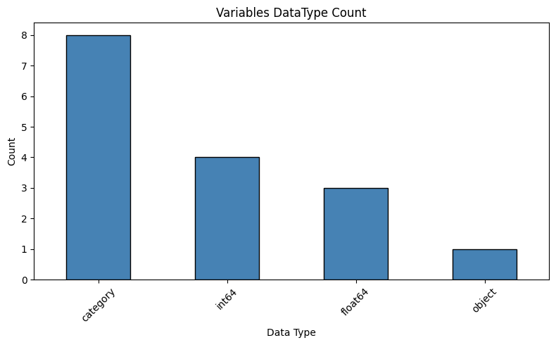

```python
dtype_counts = train_df.dtypes.astype(str).value_counts()

fig, ax = plt.subplots(figsize=(8, 5))
dtype_counts.plot(kind="bar", ax=ax, color="steelblue", edgecolor="black")
ax.set_xlabel("Data Type")
ax.set_ylabel("Count")
ax.set_title("Variables DataType Count")
plt.xticks(rotation=45)
plt.tight_layout()
plt.show()
```

### 4.2 Missing Values Visualization

Using missingno to visualize the distribution of missing values.

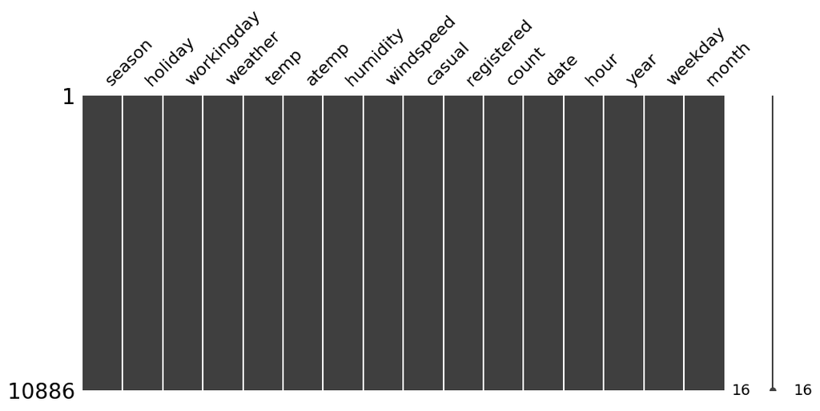

```python
msno.matrix(train_df, figsize=(12, 5))
```

### 4.3 Outliers Analysis

At first look, "count" variable contains lot of outlier data points which skews the distribution towards right (as there are more data points beyond Outer Quartile Limit). Following inferences can be made from the boxplots below:

- Spring season has got relatively lower count. The dip in median value in boxplot gives evidence for it.
- The boxplot with "Hour Of The Day" is quite interesting. The median values are relatively higher at 7AM - 8AM and 5PM - 6PM. It can be attributed to regular school and office users at that time.
- Most of the outlier points are mainly contributed from "Working Day" than "Non Working Day".

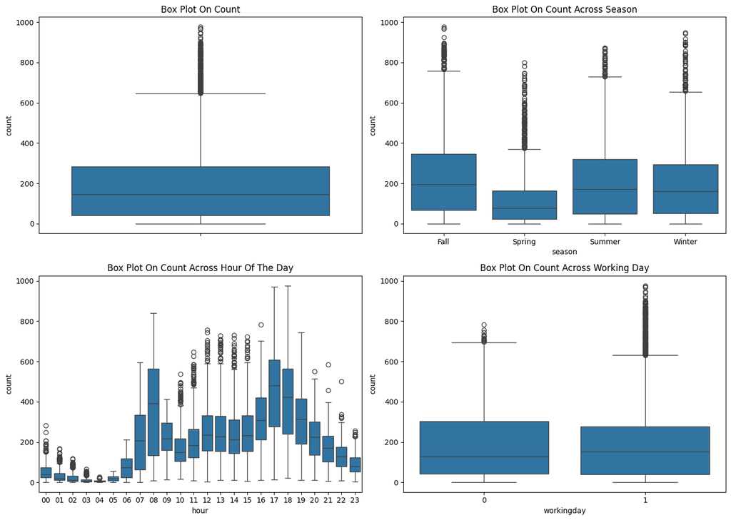

```python
fig, axes = plt.subplots(nrows=2, ncols=2, figsize=(14, 10))

sns.boxplot(data=train_df, y="count", ax=axes[0, 0])
axes[0, 0].set_title("Box Plot On Count")

sns.boxplot(data=train_df, x="season", y="count", ax=axes[0, 1])
axes[0, 1].set_title("Box Plot On Count Across Season")

sns.boxplot(data=train_df, x="hour", y="count", ax=axes[1, 0])
axes[1, 0].set_title("Box Plot On Count Across Hour Of The Day")

sns.boxplot(data=train_df, x="workingday", y="count", ax=axes[1, 1])
axes[1, 1].set_title("Box Plot On Count Across Working Day")

plt.tight_layout()
plt.show()
```

### 4.4 Correlation Analysis

One common way to understand how a dependent variable is influenced by features (numerical) is to find a correlation matrix between them.

- temp, atemp and humidity features have positive and negative correlation with count respectively.
- windspeed is not gonna be really useful numerical feature and it is visible from its correlation value with "count".
- Since "atemp" and "temp" have strong correlation with each other, meaning one of them should be dropped during model building
- "Casual" and "Registered" are not taken into account since they are leakage variables in nature and need to be dropped during model building.

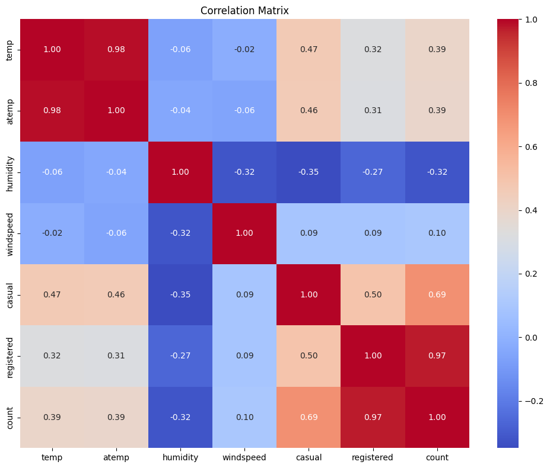

```python
corr_matrix = train_df.select_dtypes(include=["int64", "float64"]).corr()

fig, ax = plt.subplots(figsize=(10, 8))
sns.heatmap(corr_matrix, annot=True, cmap="coolwarm", fmt=".2f", ax=ax)
ax.set_title("Correlation Matrix")
plt.tight_layout()
plt.show()
```

Regression plot in seaborn is one useful way to depict the relationship between two features. Here we consider "count" vs "temp", "humidity", "windspeed".

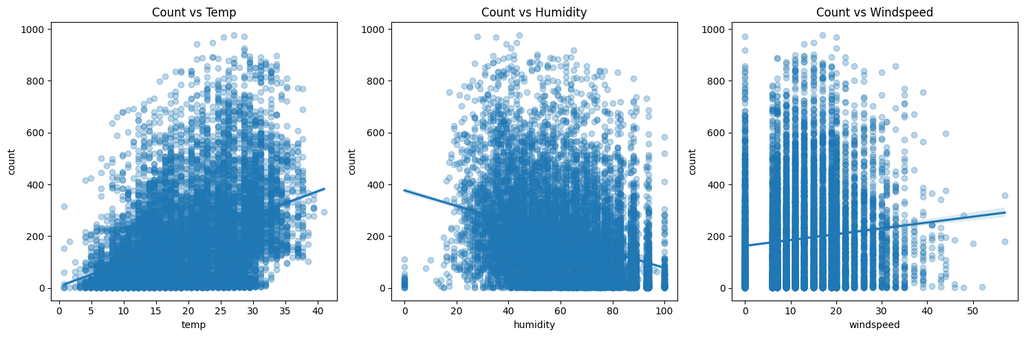

```python
fig, axes = plt.subplots(nrows=1, ncols=3, figsize=(15, 5))

sns.regplot(data=train_df, x="temp", y="count", ax=axes[0], scatter_kws={"alpha": 0.3})
axes[0].set_title("Count vs Temp")

sns.regplot(data=train_df, x="humidity", y="count", ax=axes[1], scatter_kws={"alpha": 0.3})
axes[1].set_title("Count vs Humidity")

sns.regplot(data=train_df, x="windspeed", y="count", ax=axes[2], scatter_kws={"alpha": 0.3})
axes[2].set_title("Count vs Windspeed")

plt.tight_layout()
plt.show()
```

### 4.5 Visualizing Distribution Of Data

As it is visible from the below figures that "count" variable is skewed towards right. It is desirable to have Normal distribution as most of the machine learning techniques require dependent variable to be Normal. One possible solution is to take log transformation on "count" variable. After the transformation the data looks lot better but still not ideally following normal distribution.

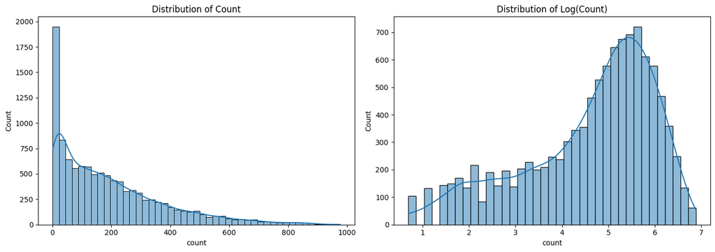

```python
fig, axes = plt.subplots(nrows=1, ncols=2, figsize=(14, 5))

sns.histplot(train_df["count"], kde=True, ax=axes[0])
axes[0].set_title("Distribution of Count")

sns.histplot(np.log1p(train_df["count"]), kde=True, ax=axes[1])
axes[1].set_title("Distribution of Log(Count)")

plt.tight_layout()
plt.show()
```

### 4.6 Visualizing Count Vs (Month, Season, Hour, Weekday, Usertype)

- It is quite obvious that people tend to rent bike during summer season since it is really conducive to ride bike at that season. Therefore June, July and August have got relatively higher demand for bicycle.
- On weekdays more people tend to rent bicycle around 7AM-8AM and 5PM-6PM. As we mentioned earlier this can be attributed to regular school and office commuters.
- Above pattern is not observed on "Saturday" and "Sunday". More people tend to rent bicycle between 10AM and 4PM.
- The peak user count around 7AM-8AM and 5PM-6PM is purely contributed by registered users.

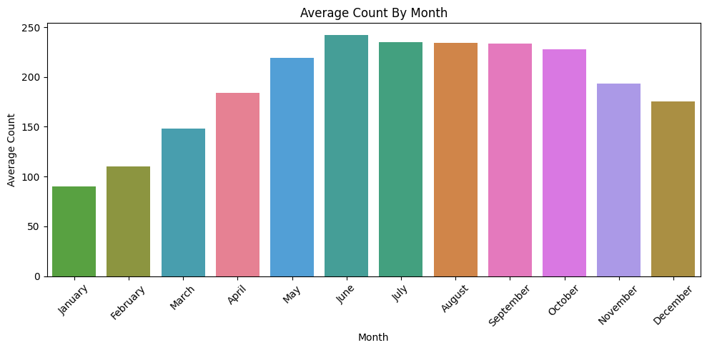

```python
month_order = ["January", "February", "March", "April", "May", "June",
               "July", "August", "September", "October", "November", "December"]

fig, ax = plt.subplots(figsize=(10, 5))
sns.barplot(data=train_df, x="month", y="count", ax=ax, errorbar=None, order=month_order,
            hue="month", palette="husl", legend=False)
ax.set_title("Average Count By Month")
ax.set_xlabel("Month")
ax.set_ylabel("Average Count")
ax.tick_params(axis="x", rotation=45)
plt.tight_layout()
plt.show()
```

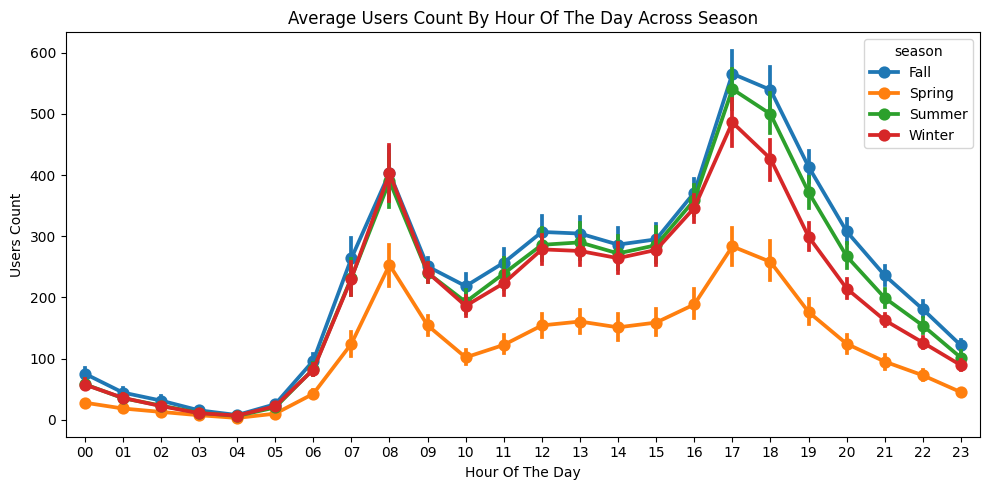

```python
fig, ax = plt.subplots(figsize=(10, 5))
sns.pointplot(data=train_df, x="hour", y="count", hue="season", ax=ax)
ax.set_title("Average Users Count By Hour Of The Day Across Season")
ax.set_xlabel("Hour Of The Day")
ax.set_ylabel("Users Count")
plt.tight_layout()
plt.show()
```

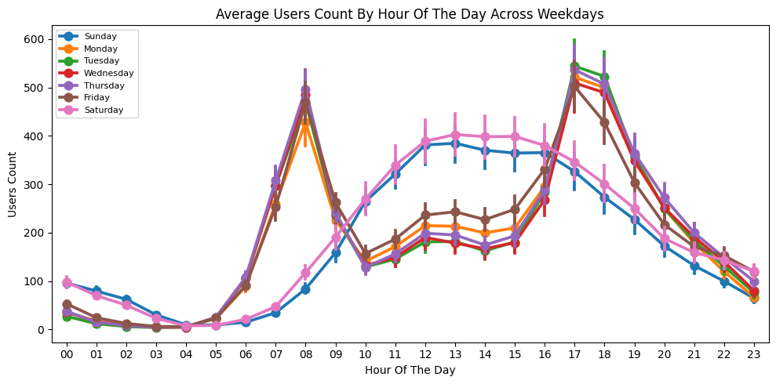

```python
weekday_order = ["Sunday", "Monday", "Tuesday", "Wednesday", "Thursday", "Friday", "Saturday"]

fig, ax = plt.subplots(figsize=(10, 5))
sns.pointplot(data=train_df, x="hour", y="count", hue="weekday", hue_order=weekday_order, ax=ax)
ax.set_title("Average Users Count By Hour Of The Day Across Weekdays")
ax.set_xlabel("Hour Of The Day")
ax.set_ylabel("Users Count")
ax.legend(loc="upper left", fontsize=8)
plt.tight_layout()
plt.show()
```

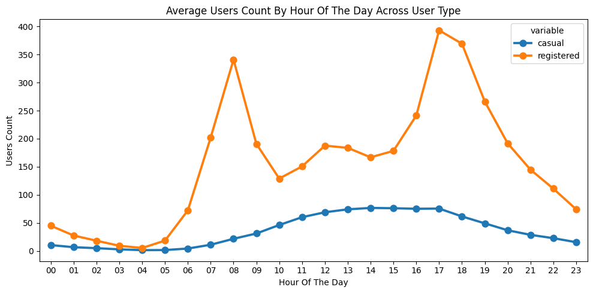

```python
hourly_data = train_df.groupby("hour")[["casual", "registered"]].mean().reset_index()
hourly_melted = hourly_data.melt(id_vars="hour", var_name="variable", value_name="count")

fig, ax = plt.subplots(figsize=(10, 5))
sns.pointplot(data=hourly_melted, x="hour", y="count", hue="variable", ax=ax)
ax.set_title("Average Users Count By Hour Of The Day Across User Type")
ax.set_xlabel("Hour Of The Day")
ax.set_ylabel("Users Count")
plt.tight_layout()
plt.show()
```

## 5. Model Building

### 5.1 Data Preparation

Before building models, we need to:

- Save test datetime for submission
- Drop leakage columns (`casual`, `registered`) - they sum to `count` and are not available in test data
- Drop `date` column - we already extracted useful features from it
- Log-transform the target variable (`count`) to handle right-skewness
- Convert categorical variables to dummy variables for linear models

```python
test_datetime = pd.read_csv("test.csv")["datetime"]

# Drop leakage columns, date, and atemp (highly correlated with temp)
drop_columns = ["casual", "registered", "date", "count", "atemp"]

y_train = np.log1p(train_df["count"])

X_train = train_df.drop(columns=drop_columns)
X_test = test_df.drop(columns=["date", "atemp"])

X_train = pd.get_dummies(X_train, drop_first=True)
X_test = pd.get_dummies(X_test, drop_first=True)

X_test = X_test.reindex(columns=X_train.columns, fill_value=0)

print(f"X_train shape: {X_train.shape}")
print(f"X_test shape: {X_test.shape}")
print(f"y_train shape: {y_train.shape}")
```

```
X_train shape: (10886, 52)
X_test shape: (6493, 52)
y_train shape: (10886,)
```

### 5.2 RMSLE Metric

The Kaggle competition uses Root Mean Squared Logarithmic Error (RMSLE) as the evaluation metric.

```python
def rmsle(y_true, y_pred):
    """Calculate RMSLE between actual and predicted values."""
    return np.sqrt(mean_squared_error(y_true, y_pred))
```

### 5.3 Model Training and Evaluation

For each model, we will:

1. Train on the full training set
2. Calculate RMSLE on training data
3. Show actual vs predicted comparison on training data
4. Show distribution of predictions on test data

```python
from sklearn.model_selection import cross_val_score

def evaluate_model(model, model_name, X_train, y_train, X_test):
    """Train model, evaluate on train, and predict on test."""
    model.fit(X_train, y_train)

    y_pred_train = model.predict(X_train)
    y_pred_test = model.predict(X_test)

    train_rmsle = rmsle(y_train, y_pred_train)

    fig, axes = plt.subplots(nrows=1, ncols=3, figsize=(18, 5))

    # Plot 1: Train actual vs predicted distribution
    sns.histplot(np.expm1(y_train), kde=True, ax=axes[0], label="Actual", color="blue", alpha=0.5)
    sns.histplot(np.expm1(y_pred_train), kde=True, ax=axes[0], label="Predicted", color="orange", alpha=0.5)
    axes[0].set_title(f"{model_name}: Train Distribution")
    axes[0].set_xlabel("Count")
    axes[0].legend()

    # Plot 2: Train actual vs predicted scatter
    axes[1].scatter(y_train, y_pred_train, alpha=0.3)
    axes[1].plot([y_train.min(), y_train.max()], [y_train.min(), y_train.max()], "r--", lw=2)
    axes[1].set_xlabel("Actual (log)")
    axes[1].set_ylabel("Predicted (log)")
    axes[1].set_title(f"{model_name}: Train Actual vs Predicted")

    # Plot 3: Test predictions distribution
    sns.histplot(np.expm1(y_pred_test), kde=True, ax=axes[2], color="green")
    axes[2].set_title(f"{model_name}: Test Predictions Distribution")
    axes[2].set_xlabel("Predicted Count")

    plt.suptitle(f"{model_name} - Train RMSLE: {train_rmsle:.4f}", fontsize=14, fontweight="bold")
    plt.tight_layout()
    plt.show()

    return y_pred_train, y_pred_test, train_rmsle
```

#### Linear Regression

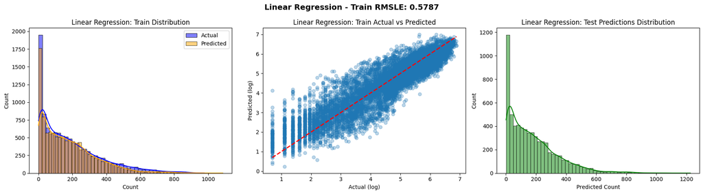

```python
lr_model = LinearRegression()
y_pred_train_lr, y_pred_test_lr, rmsle_lr = evaluate_model(lr_model, "Linear Regression", X_train, y_train, X_test)
```

#### Ridge Regression

```
Best Ridge params: {'alpha': 1.0129197956845737}
```

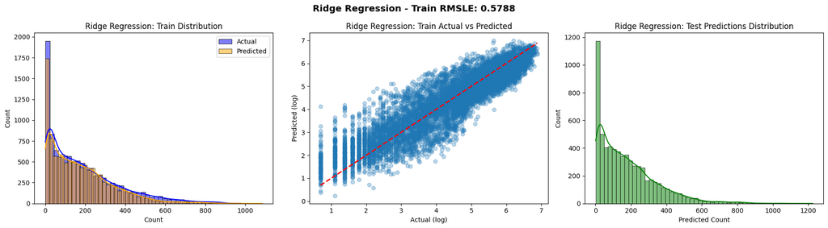

```python
def ridge_objective(trial):
    alpha = trial.suggest_float("alpha", 0.001, 100, log=True)
    model = Ridge(alpha=alpha)
    scores = cross_val_score(model, X_train, y_train, cv=5, scoring="neg_root_mean_squared_error")
    return -scores.mean()

optuna.logging.set_verbosity(optuna.logging.WARNING)
ridge_study = optuna.create_study(direction="minimize", sampler=TPESampler(seed=42))
ridge_study.optimize(ridge_objective, n_trials=30, show_progress_bar=True)

print(f"Best Ridge params: {ridge_study.best_params}")
ridge_model = Ridge(**ridge_study.best_params)
y_pred_train_ridge, y_pred_test_ridge, rmsle_ridge = evaluate_model(ridge_model, "Ridge Regression", X_train, y_train, X_test)
```

#### Lasso Regression

```
Best Lasso params: {'alpha': 0.00032446474808171187}
```

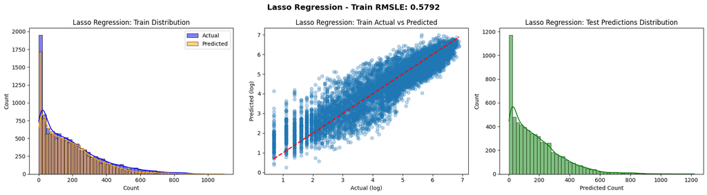

```python
def lasso_objective(trial):
    alpha = trial.suggest_float("alpha", 0.0001, 1, log=True)
    model = Lasso(alpha=alpha)
    scores = cross_val_score(model, X_train, y_train, cv=5, scoring="neg_root_mean_squared_error")
    return -scores.mean()

lasso_study = optuna.create_study(direction="minimize", sampler=TPESampler(seed=42))
lasso_study.optimize(lasso_objective, n_trials=30, show_progress_bar=True)

print(f"Best Lasso params: {lasso_study.best_params}")
lasso_model = Lasso(**lasso_study.best_params)
y_pred_train_lasso, y_pred_test_lasso, rmsle_lasso = evaluate_model(lasso_model, "Lasso Regression", X_train, y_train, X_test)
```

#### Random Forest

```
Best Random Forest params: {'n_estimators': 110, 'max_depth': 30, 'min_samples_split': 7, 'min_samples_leaf': 2}
```

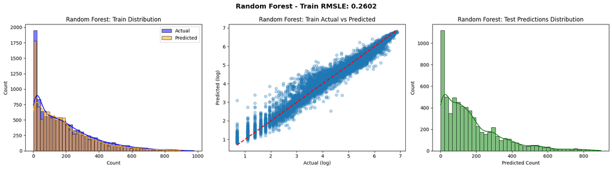

```python
def rf_objective(trial):
    params = {
        "n_estimators": trial.suggest_int("n_estimators", 100, 500),
        "max_depth": trial.suggest_int("max_depth", 10, 50),
        "min_samples_split": trial.suggest_int("min_samples_split", 2, 10),
        "min_samples_leaf": trial.suggest_int("min_samples_leaf", 1, 4),
        "random_state": 42,
        "n_jobs": -1
    }
    model = RandomForestRegressor(**params)
    scores = cross_val_score(model, X_train, y_train, cv=3, scoring="neg_root_mean_squared_error")
    return -scores.mean()

rf_study = optuna.create_study(direction="minimize", sampler=TPESampler(seed=42))
rf_study.optimize(rf_objective, n_trials=20, show_progress_bar=True)

print(f"Best Random Forest params: {rf_study.best_params}")
rf_model = RandomForestRegressor(**rf_study.best_params, random_state=42, n_jobs=-1)
y_pred_train_rf, y_pred_test_rf, rmsle_rf = evaluate_model(rf_model, "Random Forest", X_train, y_train, X_test)
```

#### XGBoost

```
Best XGBoost params: {'n_estimators': 389, 'learning_rate': 0.18212061804930277, 'max_depth': 7, 'subsample': 0.867116979833637, 'colsample_bytree': 0.8145366644964592}
```

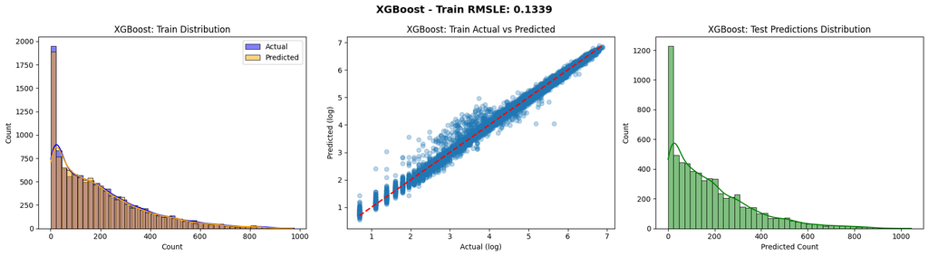

```python
def xgb_objective(trial):
    params = {
        "n_estimators": trial.suggest_int("n_estimators", 100, 500),
        "learning_rate": trial.suggest_float("learning_rate", 0.01, 0.3, log=True),
        "max_depth": trial.suggest_int("max_depth", 3, 12),
        "subsample": trial.suggest_float("subsample", 0.6, 1.0),
        "colsample_bytree": trial.suggest_float("colsample_bytree", 0.6, 1.0),
        "random_state": 42,
        "n_jobs": -1
    }
    model = XGBRegressor(**params)
    scores = cross_val_score(model, X_train, y_train, cv=3, scoring="neg_root_mean_squared_error")
    return -scores.mean()

xgb_study = optuna.create_study(direction="minimize", sampler=TPESampler(seed=42))
xgb_study.optimize(xgb_objective, n_trials=30, show_progress_bar=True)

print(f"Best XGBoost params: {xgb_study.best_params}")
xgb_model = XGBRegressor(**xgb_study.best_params, random_state=42, n_jobs=-1)
y_pred_train_xgb, y_pred_test_xgb, rmsle_xgb = evaluate_model(xgb_model, "XGBoost", X_train, y_train, X_test)
```

### 5.4 Model Comparison

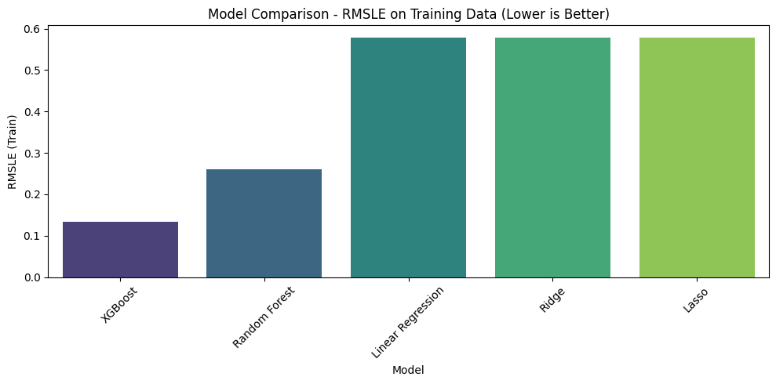

```
            Model  RMSLE (Train)
          XGBoost       0.133869
    Random Forest       0.260219
Linear Regression       0.578700
            Ridge       0.578776
            Lasso       0.579222

Best Model: XGBoost
```

```python
results = {
    "Linear Regression": rmsle_lr,
    "Ridge": rmsle_ridge,
    "Lasso": rmsle_lasso,
    "Random Forest": rmsle_rf,
    "XGBoost": rmsle_xgb
}

results_df = pd.DataFrame(list(results.items()), columns=["Model", "RMSLE (Train)"]).sort_values(by="RMSLE (Train)")

fig, ax = plt.subplots(figsize=(10, 5))
sns.barplot(data=results_df, x="Model", y="RMSLE (Train)", ax=ax, hue="Model", palette="viridis", legend=False)
ax.set_title("Model Comparison - RMSLE on Training Data (Lower is Better)")
ax.tick_params(axis="x", rotation=45)
plt.tight_layout()
plt.show()

print(results_df.to_string(index=False))
print(f"\nBest Model: {results_df.iloc[0]['Model']}")
```

### 5.5 Create Submission

Creating submission file using the best performing model (based on training RMSLE).

```python
best_predictions = {
    "Linear Regression": y_pred_test_lr,
    "Ridge": y_pred_test_ridge,
    "Lasso": y_pred_test_lasso,
    "Random Forest": y_pred_test_rf,
    "XGBoost": y_pred_test_xgb
}

best_model_name = results_df.iloc[0]["Model"]
best_pred_log = best_predictions[best_model_name]
best_pred_count = np.expm1(best_pred_log)
best_pred_count = np.maximum(best_pred_count, 0)

submission = pd.DataFrame({
    "datetime": test_datetime,
    "count": best_pred_count.astype(int)
})

submission.to_csv("submission.csv", index=False)

print(f"Submission created using {best_model_name}!")
print(f"\nSubmission preview:")
print(submission.head(10))
print(f"\nSubmission shape: {submission.shape}")
```

```
Submission created using XGBoost!

Submission preview:
              datetime  count
0  2011-01-20 00:00:00     18
1  2011-01-20 01:00:00      3
2  2011-01-20 02:00:00      4
3  2011-01-20 03:00:00      3
4  2011-01-20 04:00:00      1
5  2011-01-20 05:00:00      4
6  2011-01-20 06:00:00     37
7  2011-01-20 07:00:00     99
8  2011-01-20 08:00:00    188
9  2011-01-20 09:00:00    126

Submission shape: (6493, 2)
```